# Relatório de Avaliação do PGD IFPE (MINUTA)

Análise anual 2025

Autor

Prodin

Data de Publicação

15 de outubro de 2026

**ImportanteATENÇÃO AOS PRAZOS**

§ 1º Os resultados da avaliação relativa à execução do PGD no **ano de 2025 deverão ser publicados até 30 de novembro de 2026.**

§ 2º Os resultados da avaliação relativa à execução do PGD no **ano de 2026, e nos anos seguintes, deverão ser publicados até 30 de abril do ano subsequente.**

**DicaEstrutura mínima**

segue abaixo os item de 1 a 5, esses corresponde a estrutura mínima sugerida pelo MGI o item 6 corresponde aos resultados de nossa pesquisa

# 1 Gestão de resultados

No IFPE servidores habilitados são os serivodores TAEs e Docentes que possuem algma função administrativa assim totalizando 1262, desses temos, 539.

essa força de trabalho desemvolveu durante o ano os seguintes resultados

- Total de contribuições do Sevidores: 28375 planejadas das quais 96.3% concluidas.
- Total de Entregas de Setor: 6079 planejadas das quais 83.68% concluidas.

Essas ações agrupas em 5210 planos de trabalhos e 331 planos de entregas distribuidos durante todo ano de 2025.

outros dados podem ser consultados no painel PGD institucional pelo link [PGD em Números](https://datastudio.google.com/u/0/reporting/802d6a39-949f-48f3-a0c5-8fea10ce16cd/page/xCelD/edit?s=kQhUKt2wq40)

# 2 Planejamento institucional;

# 3 Otimização na gestão de recursos;

# 4 Gestão de processos;

# 5 Gestão de pessoas.

**NotaDados da pesquisa**

**Público:** Servidores participantes do PGD.

**Total de resposnta:** 125

# 6 AVALIAÇÃO INSTITUICIONAL

## Introdução

Este relatório apresenta uma visão geral das respostas ao formulário de avaliação do PGD no ambito do IFPE. O formulário foi aplicado aos servidores que participantes por meio de google forms com respostas expontânea.

segue itens a serem observado segundo RESOLUÇÃO CPGD/MGI Nº 7, DE 24 DE SETEMBRO DE 2026

## 6.1 Perfil dos Servidores em PGD respondentes

Características gerais do perfil.

### 6.1.1 Faixa de Idade

[interactive chart not shown]

### 6.1.2 Qual o gênero?

[interactive chart not shown]

### 6.1.3 Possui filhos até 12 anos

[interactive chart not shown]

## 6.2 Dimencionamento

### 6.2.1 Qual sua unidade?

[interactive chart not shown]

### 6.2.2 Possui Cargo?

[interactive chart not shown]

### 6.2.3 Tipo de função

[interactive chart not shown]

### 6.2.4 Qual o regime de execução de PGD você participa?

[interactive chart not shown]

### 6.2.5 Como você executa seu PGD?

[interactive chart not shown]

## 6.3 Conhecimento das Normas e documento legais

### 6.3.1 Você leu o regulamento interno (Resolução e o Edital)?

[interactive chart not shown]

### 6.3.2 Com qual frequência você acessa o sistema do PGD?

[interactive chart not shown]

### 6.3.3 Na sua unidade, além do sistema PGD, há alguma outra forma de acompanhamento das entregas das atividades?

[interactive chart not shown]

#### 6.3.3.1 Núvem de palavras das respostas citadas

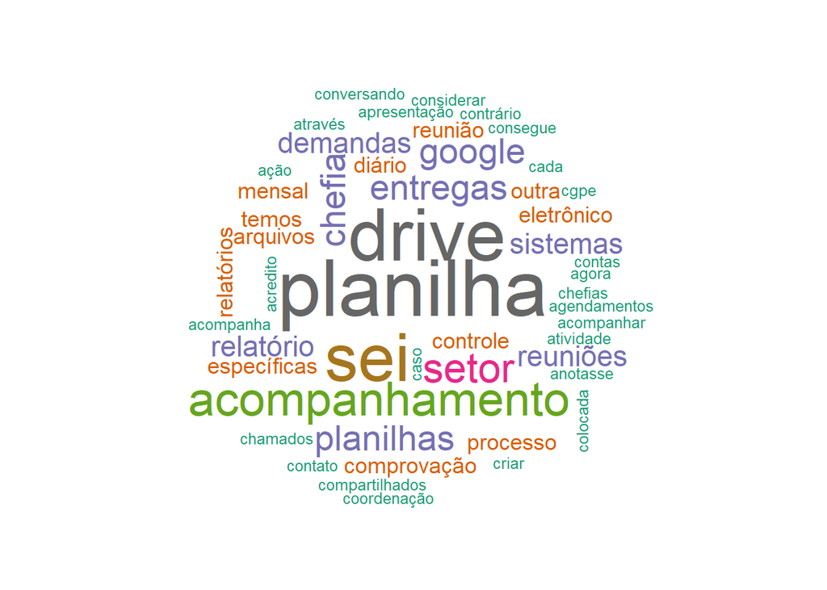

### 6.3.4 Você tem conhecimento das principais novidades do PGD trazidas pela nova portaria?

[interactive chart not shown]

## 6.4 Na sua opinião avalie os fatores que contribuiem

Nessa seção, dividiu-se em bloco para otimizar e facilitar a analise de questão abaixo:

A seguir, assinale a opção que mais se adequa ao seu nível de concordância com as afirmações abaixo relativas ao teletrabalho, sendo “1” discordo totalmente, “2” discordo um pouco, “3” Não discordo nem concordo, “4” Concordo um pouco e “5” concordo totalmente.

### 6.4.1 Bloco - 1

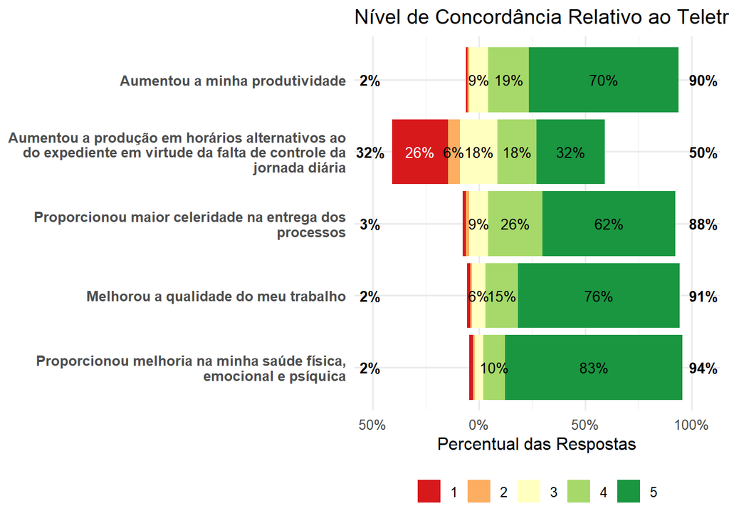

### 6.4.2 Bloco - 2

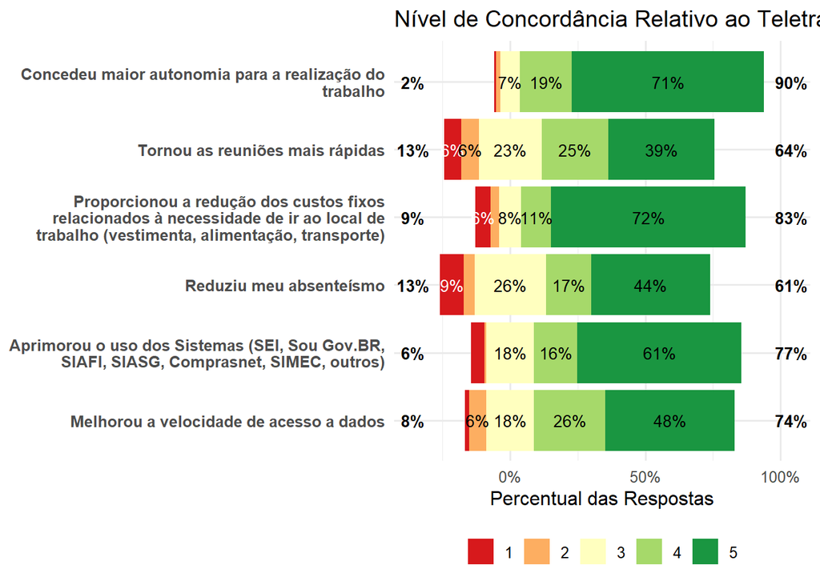

### 6.4.3 Bloco - 3

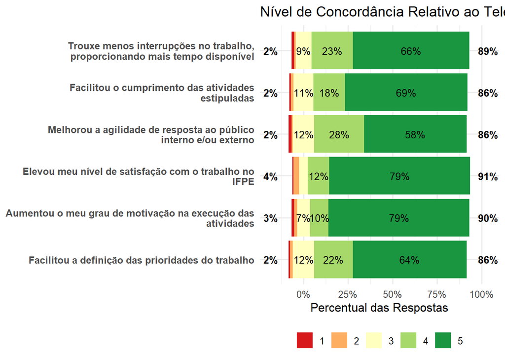

### 6.4.4 Bloco - 4

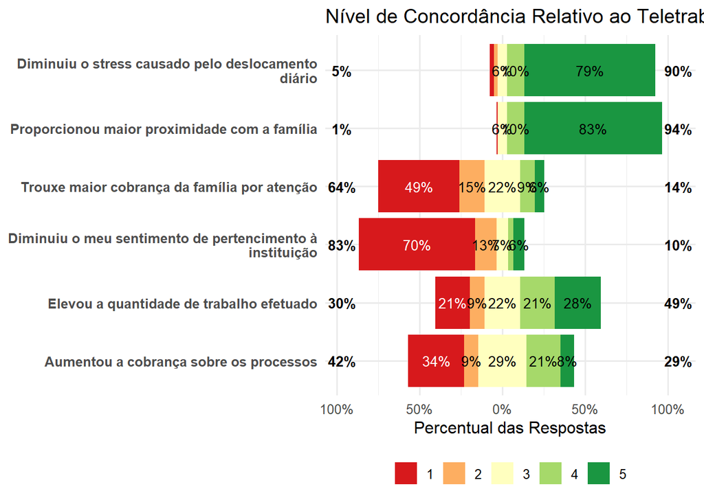

### 6.4.5 Bloco - 5

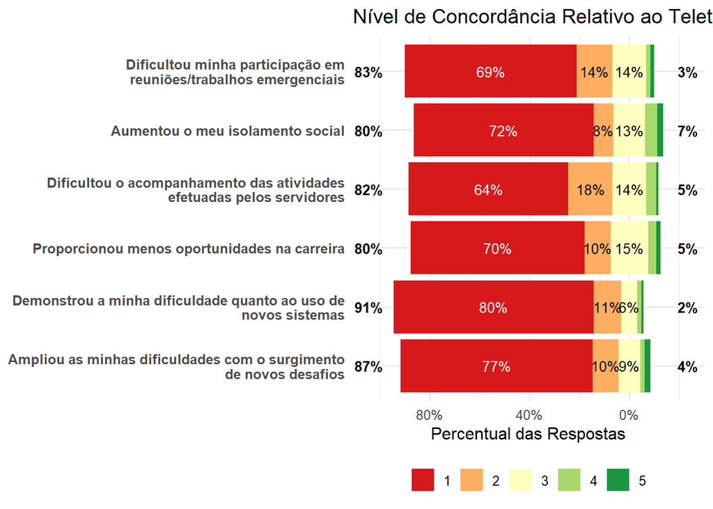

### 6.4.6 Bloco - 6

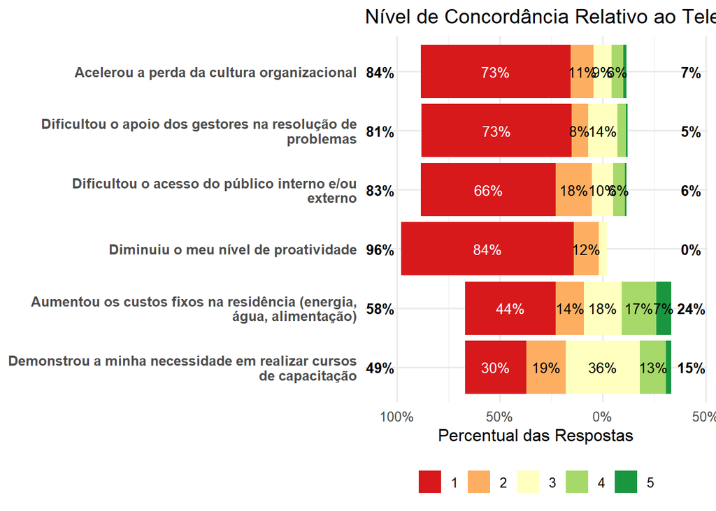

### 6.4.7 Bloco - 7

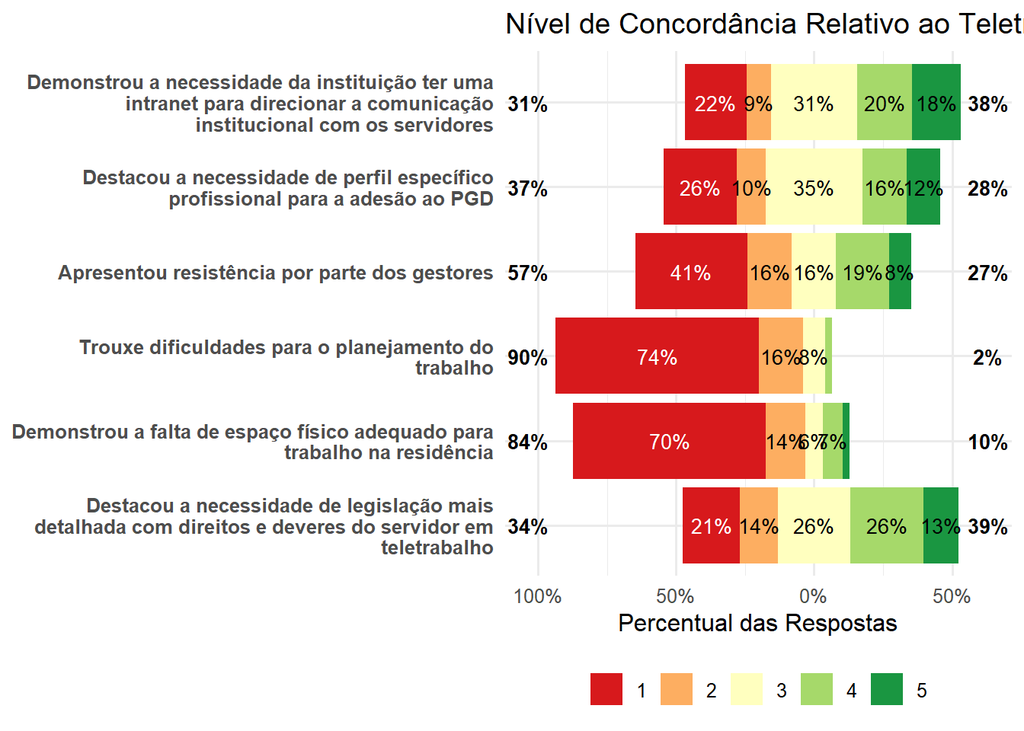

### 6.4.8 Bloco - 8

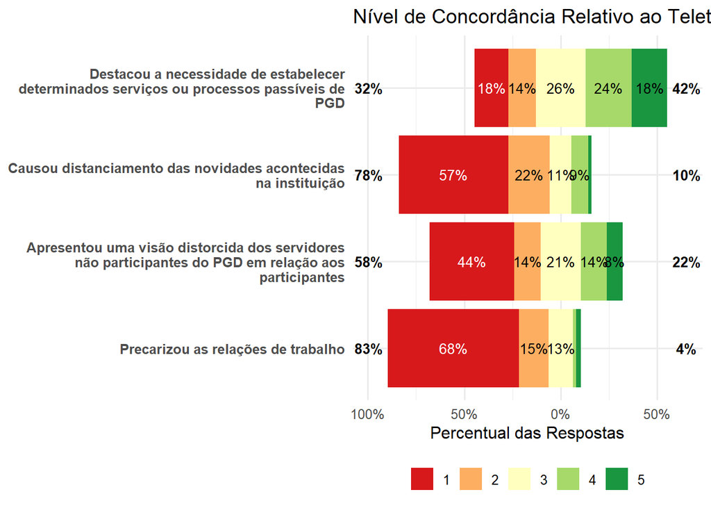

### 6.4.9 Apresento feedback à minha chefia imediata das minhas entregas e dificuldades enfrentadas?

[interactive chart not shown]

## 6.5 Dificuldades

### 6.5.1 Quais dessas dificuldades você sente de forma mais frequente durante a execução do PGD? (Pode marcar mais de uma opção)

[interactive chart not shown]

### 6.5.2 As entregas dos seus planos de trabalho são devidamente avaliadas pela chefia imediata?

[interactive chart not shown]

### 6.5.3 Você recebe feedback das suas entregas pela chefia imediata?

[interactive chart not shown]

### 6.5.4 Considerando a sua relação com outras unidades, assinale a opção que mais se adequa ao seu nível de concordância com as afirmações abaixo, sendo “1” discordo totalmente, “2” discordo um pouco, “3” Não discordo nem concordo, “4” Concordo um pouco e “5” concordo totalmente.

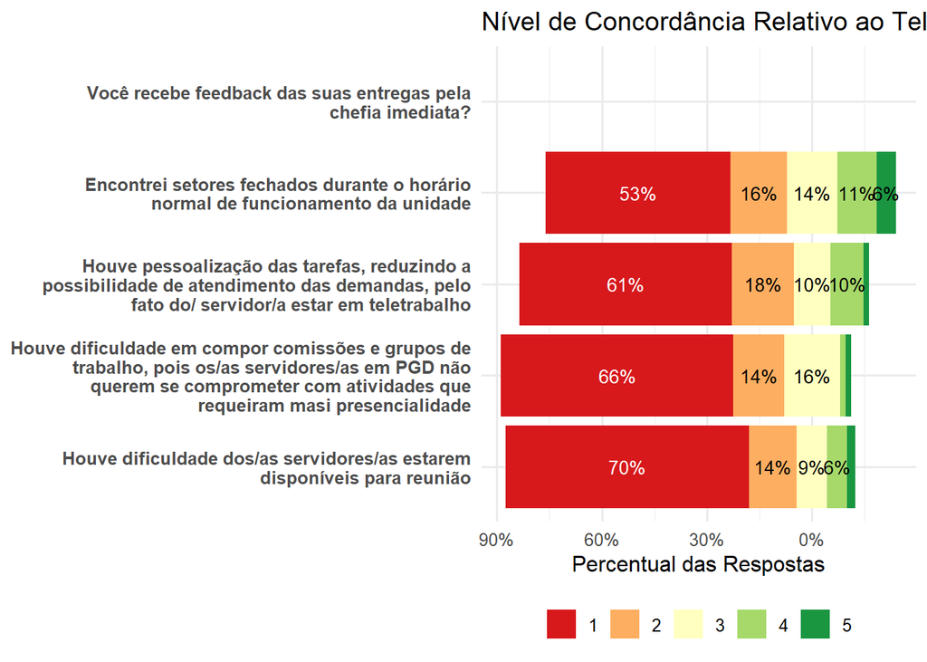

### 6.5.5 Como você avalia a sua participação no PGD?

#### 6.5.5.1 Núvem de palavras das respostas citadas

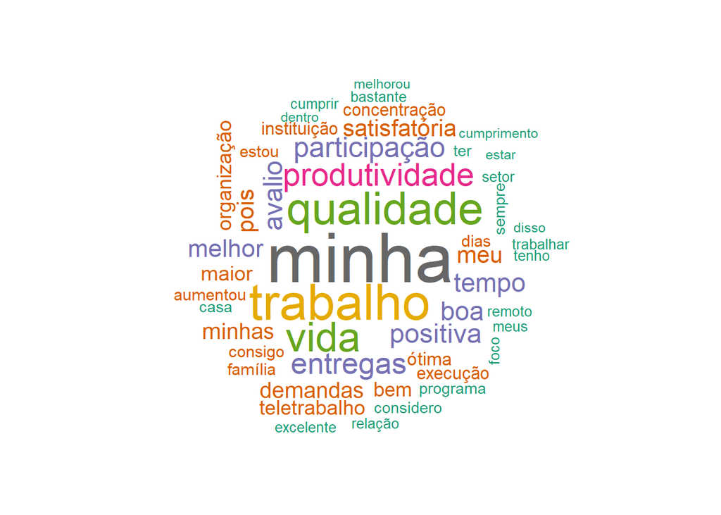

### 6.5.6 Registre aqui seu comentário e/ou sugestão para o aperfeiçoamento do PGD no IFPE:

#### 6.5.6.1 Núvem de palavras das respostas citadas

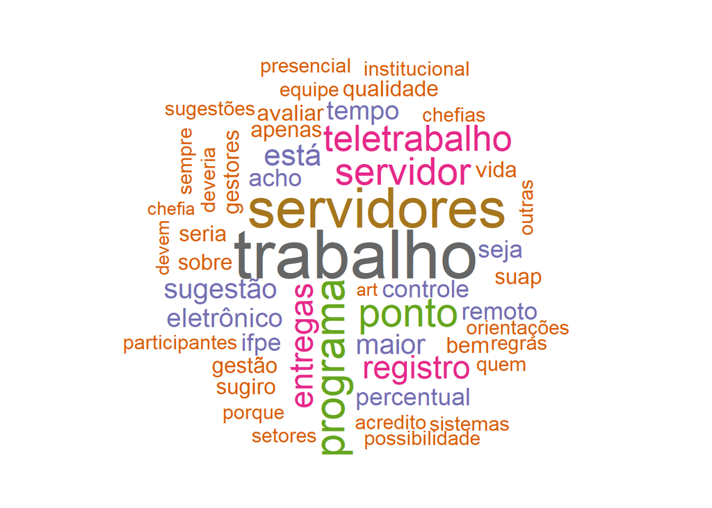